# Concentration of S&P 500 index

In this data challege we study how concentrated the S&P 500 is among its constituent companies.

1. The S&P 500 (Standard & Poor’s 500) is a stock market index that tracks the performance of 500 of the largest publicly traded companies in the United States.
2. It covers roughly 80% of the total value of the U.S. stock market.
3. It is a market-capitalization-weighted index. Larger companies have a much bigger impact on its value than smaller components

We will use:

```r
library(tidyverse)
library(tidyquant)
library(ineq)
```

The three packages have different roles:

```
tidyquant    retrieve the S&P 500 constituents and weights
tidyverse    manipulate and visualize the data
ineq         calculate the Lorenz curve and Gini coefficient
```

Our main questions are:

1. How unequal are the company weights in the S&P 500?
2. How much of the index is represented by its largest companies?
3. What does the Lorenz curve tell us about concentration?
4. What is the Gini coefficient of the S&P 500 weights?

## Domanda 1: Quanto sono ineguali i pesi delle aziende nell’S&P 500?

Per prima cosa dobbiamo importare i dati e poi calcolare la media, la mediana, il massimo e il minimo per vedere come sono distribuiti.

```r
# Importazione del dataset
sp500_weights <- tq_index("SP500")

sp500_weights %>%
  summarise(
    peso_medio = mean(weight),
    peso_mediano = median(weight),
    peso_max = max(weight),
    peso_min = min(weight)
  )
```

```
## # A tibble: 1 × 4
##   peso_medio peso_mediano peso_max     peso_min
##        <dbl>        <dbl>    <dbl>        <dbl>
## 1    0.00198     0.000678   0.0777 0.0000000300
```

Peso Medio (0.00198 $\approx$ 0.20%): Rappresenta il peso teorico medio che ogni azienda avrebbe se l’indice fosse perfettamente equamente ponderato (vicino al benchmark ideale di $1/500 = 0.002$).

Peso Mediano (0.00068 $\approx$ 0.07%): Il valore centrale della distribuzione. Il fatto che la mediana sia significativamente inferiore alla media indica una forte asimmetria positiva (right-skewness): la stragrande maggioranza delle aziende ha un peso estremamente ridotto e si posiziona al di sotto della media.

Peso Massimo (0.0777 $\approx$ 7.77%): Il peso della singola azienda dominante all’interno dell’indice. Questo valore evidenzia come un unico gigante tecnologico o finanziario detenga quasi l’8% dell’intero paniere statunitense.

Peso Minimo (3.00e-08 $\approx$ 0.000003%): Il peso quasi nullo assegnato alle aziende a minore capitalizzazione presenti nella parte inferiore della classifica.

```r
# Vede le prime 10 aziende per peso
top_10 <- sp500_weights %>%
  arrange(desc(weight)) %>%
  slice(1:10)

top_10
```

```
## # A tibble: 10 × 8
##    symbol company      identifier sedol weight sector shares_held local_currency
##    <chr>  <chr>        <chr>      <chr>  <dbl> <chr>        <dbl> <chr>
##  1 NVDA   NVIDIA CORP  67066G104  2379… 0.0777 -        295174623 USD
##  2 AAPL   APPLE INC    037833100  2046… 0.0766 -        178010005 USD
##  3 MSFT   MICROSOFT C… 594918104  2588… 0.0592 -         90565510 USD
##  4 AMZN   AMAZON.COM … 023135106  2000… 0.0360 -        119717349 USD
##  5 GOOGL  ALPHABET IN… 02079K305  BYVY… 0.0250 -         71570895 USD
##  6 AVGO   BROADCOM INC 11135F101  BDZ7… 0.0247 -         58028266 USD
##  7 META   META PLATFO… 30303M102  B7TL… 0.0207 -         26896058 USD
##  8 GOOG   ALPHABET IN… 02079K107  BYY8… 0.0202 -         57975370 USD
##  9 TSLA   TESLA INC    88160R101  B616… 0.0171 -         34376028 USD
## 10 LLY    ELI LILLY +… 532457108  2516… 0.0165 -          9760223 USD
```

```r
# Somma il loro peso complessivo
sum(top_10$weight)
```

```
## [1] 0.3736399
```

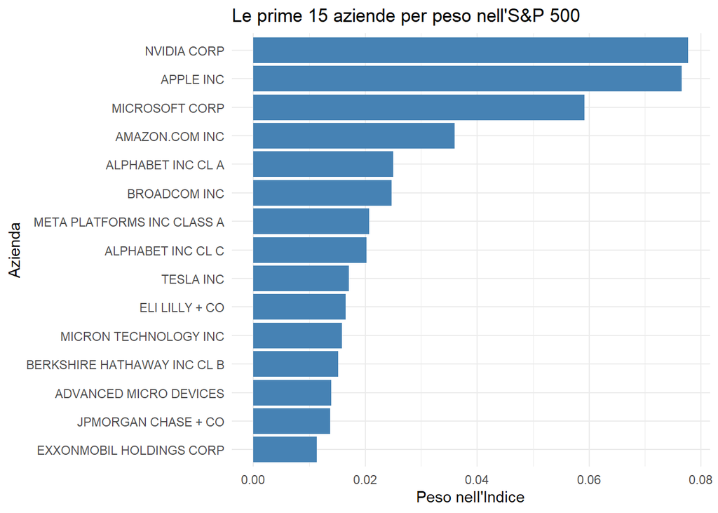

```r
sp500_weights %>%
  arrange(desc(weight)) %>%
  slice(1:15) %>%
  ggplot(aes(x = weight, y = reorder(company, weight))) +
  geom_col(fill = "steelblue") +
  labs(
    title = "Le prime 15 aziende per peso nell'S&P 500",
    x = "Peso nell'Indice",
    y = "Azienda"
  ) +
  theme_minimal()
```

Quota delle Top 10 (37.36%): La somma dei pesi delle prime 10 aziende mostra che sole 10 società (su un totale di circa 500) controllano oltre un terzo del valore dell’intero indice

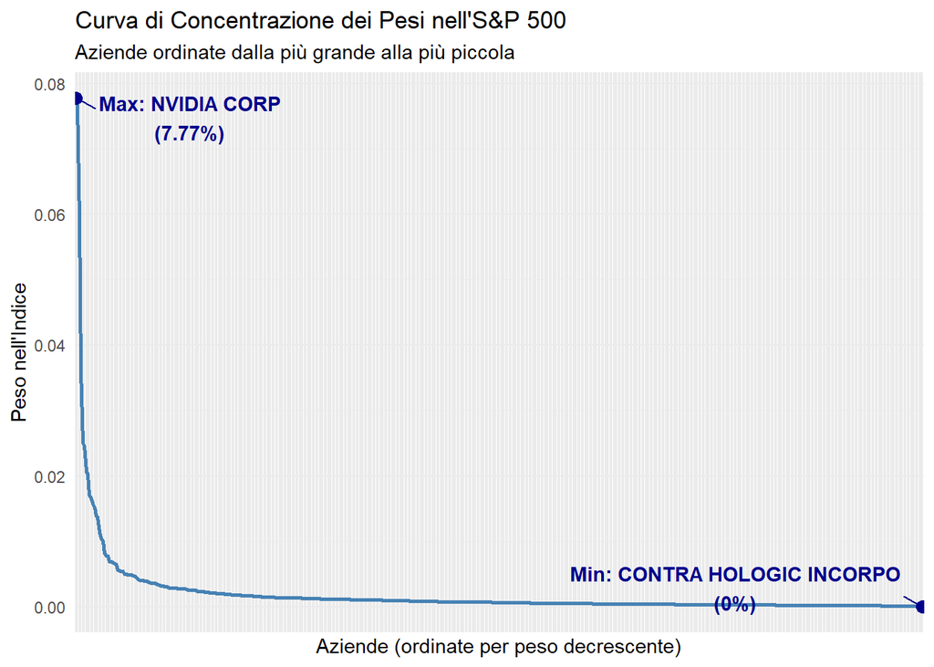

```r
library(ggplot2)
library(ggrepel) # per le etichette di testo

# 1. Ordiniana il dataset e fissio l'ordine decrescente per l'asse X
sp500_sorted <- sp500_weights %>%
  arrange(desc(weight)) %>%
  mutate(company_f = factor(company, levels = company))

# 2. Estrapolo il MASSIMO (prima azienda) e il MINIMO (ultima azienda)
azienda_max <- sp500_sorted %>% slice(1)
azienda_min <- sp500_sorted %>% slice(n())

# 3. Crea il grafico
ggplot(sp500_sorted, aes(x = company_f, y = weight, group = 1)) +
  # Uso linewidth invece di size per le linee
  geom_line(color = "steelblue", linewidth = 1) +

  # Usiamo size per i punti (qui è corretto)
  geom_point(data = azienda_max, color = "darkblue", size = 3) +
  geom_text_repel(
    data = azienda_max,
    aes(label = paste0("Max: ", company, "\n(", round(weight * 100, 2), "%)")),
    box.padding = 0.8, color = "darkblue", fontface = "bold"
  ) +

  geom_point(data = azienda_min, color = "darkblue", size = 3) +
  geom_text_repel(
    data = azienda_min,
    aes(label = paste0("Min: ", company, "\n(", round(weight * 100, 2), "%)")),
    box.padding = 0.8, color = "darkblue", fontface = "bold"
  ) +

  labs(
    title = "Curva di Concentrazione dei Pesi nell'S&P 500",
    subtitle = "Aziende ordinate dalla più grande alla più piccola",
    x = "Aziende (ordinate per peso decrescente)",
    y = "Peso nell'Indice"
  ) +
  theme_minimal() +
  theme(
    axis.text.x = element_blank(),
    axis.ticks.x = element_blank()
  )
```

Il grafico conferma che l’S&P 500, pur essendo un indice diversificato per numero di componenti, presenta una **struttura marcatamente ineguale** a causa della sua natura *market-capitalization-weighted*. La performance complessiva dell’indice risulta quindi fortemente dipendente dall’andamento di poche aziende leader, mentre la coda di centinaia di aziende minori ha un impatto marginale sul valore complessivo.

## Domanda 2: Quanto dell’indice è rappresentato dalle sue aziende più grandi?

Per rispondere a questa domanda bisogna analizzare quanta fetta dell’indice viene occupata progressivamente dalle prime 5, 10, 25, 5 e 100 aziende.

```r
# 1. Creazione della tabella con il calcolo cumulativo
sp500_cumulativo <- sp500_weights %>%
  arrange(desc(weight)) %>%
  mutate(
    rank = row_number(),                 # Posizione in classifica (1 = la più grande)
    peso_cumulativo = cumsum(weight)     # Somma progressiva dei pesi
  )

# 2. Ispezione delle soglie chiave (es. top 5, 10, 25, 50, 100)
sp500_cumulativo %>%
  filter(rank %in% c(5, 10, 25, 50, 100, 250)) %>%
  select(rank, company, weight, peso_cumulativo)
```

```
## # A tibble: 6 × 4
##    rank company             weight peso_cumulativo
##   <int> <chr>                <dbl>           <dbl>
## 1     5 ALPHABET INC CL A 0.0250             0.274
## 2    10 ELI LILLY + CO    0.0165             0.374
## 3    25 CISCO SYSTEMS INC 0.00644            0.521
## 4    50 MORGAN STANLEY    0.00339            0.632
## 5   100 LOWE S COS INC    0.00175            0.751
## 6   250 EVERPURE INC A    0.000685           0.913
```

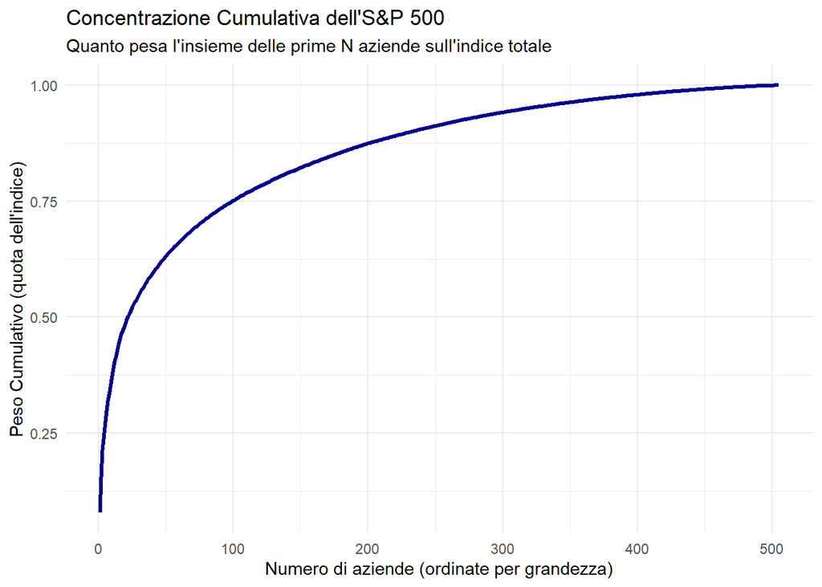

```r
ggplot(sp500_cumulativo, aes(x = rank, y = peso_cumulativo)) +
  geom_line(color = "darkblue", linewidth = 1.2) +
  labs(
    title = "Concentrazione Cumulativa dell'S&P 500",
    subtitle = "Quanto pesa l'insieme delle prime N aziende sull'indice totale",
    x = "Numero di aziende (ordinate per grandezza)",
    y = "Peso Cumulativo (quota dell'indice)"
  ) +
  theme_minimal()
```

L’analisi della somma cumulata dei pesi dimostra che l’S&P 500 è fortemente sbilanciato verso i suoi componenti di maggiori dimensioni. La concentrazione cresce in modo esponenziale nei primi ranghi:

- Le prime **25 aziende** (appena il 5% del totale dei costituenti) rappresentano la **maggioranza assoluta del mercato (~52.1%)**.
- Le prime **100 aziende** coprono ben **tre quarti (75.1%)** del valore complessivo dell’indice.

Questo evidenzia che, nonostante l’S&P 500 sia considerato l’emblema della diversificazione azionaria statunitense, la sua performance effettiva è guidata in modo preponderante da un oligopolio ristretto di grandi aziende.

## Domanda 3: Cosa ci dice la curva di Lorenz sulla concentrazione?

La Curva di Lorenz mette in relazione la **quota cumulativa delle aziende** (asse X) con la **quota cumulativa dei pesi** (asse Y), confrontandola con la cosiddetta *linea dell’uguaglianza perfetta* (la diagonale a 45 gradi, dove il 10% delle aziende possiede il 10% del peso, il 20% possiede il 20%, ecc.).

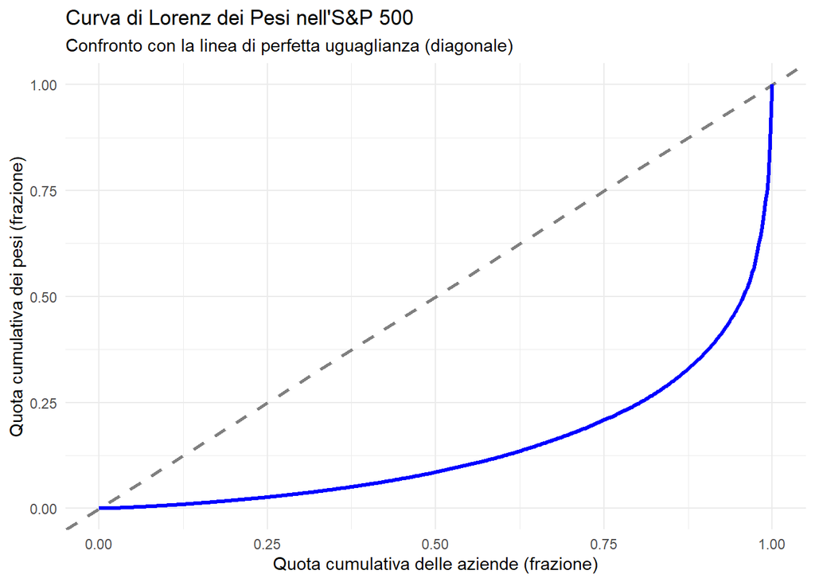

```r
# 1. Calcola la Curva di Lorenz sui pesi dell'S&P 500
curva_lorenz <- Lc(sp500_weights$weight)
# p = quota cumulativa delle aziende, e L = quota cumulativa del peso

# Conversione dei dati di Lorenz in un data frame
lorenz_df <- tibble(
  p = curva_lorenz$p, # Quota cumulativa delle aziende (da 0 a 1)
  L = curva_lorenz$L  # Quota cumulativa dei pesi (da 0 a 1)
)

# Creazione del grafico con ggplot2
ggplot(lorenz_df, aes(x = p, y = L)) +
  # Linea di perfetta uguaglianza (diagonale a 45 gradi)
  geom_abline(intercept = 0, slope = 1, linetype = "dashed", color = "gray50", linewidth = 1) +
  # Curva di Lorenz effettiva
  geom_line(color = "blue", linewidth = 1.2) +
  labs(
    title = "Curva di Lorenz dei Pesi nell'S&P 500",
    subtitle = "Confronto con la linea di perfetta uguaglianza (diagonale)",
    x = "Quota cumulativa delle aziende (frazione)",
    y = "Quota cumulativa dei pesi (frazione)"
  ) +
  theme_minimal()
```

Il grafico mostra la significativa disuguaglianza rispetto all’uguaglianza perfetta (linea trateggiata) del mercato azionario statunitense.

## Domanda 4: Cos’è il coefficiente di Gini del peso delle S&P 500?

Il coefficiente di Gini sintetizza l’intera Curva di Lorenz in un unico numero compreso tra **0** (uguaglianza perfetta: tutte le aziende hanno lo stesso peso) e **1** (massima disuguaglianza assoluta: un’azienda possiede il 100% del peso e tutte le altre zero).

```r
# Calcola il coefficiente di Gini sui pesi dell'S&P 500
indice_gini <- ineq(sp500_weights$weight, type = "Gini")


indice_gini
```

```
## [1] 0.7116953
```

### Conclusioni

L’analisi quantitativa condotta sulla struttura dei pesi dell’indice S&P 500 rivela un livello di concentrazione e disuguaglianza del capitale eccezionalmente elevato.

- **Asimmetria della Distribuzione:** La forte discrepanza tra la media ($0.20\%$) e la mediana ($0.07\%$) conferma un’asimmetria positiva accentuata. La stragrande maggioranza dei 500 componenti detiene un peso del tutto marginale sulle dinamiche del paniere.
- **Dominio al Vertice:** La concentrazione cumulativa evidenzia una spinta oligarchica **sole 10 aziende controllano oltre il** $37\%$ dell’indice, mentre **le prime 25 costituenti rappresentano la maggioranza assoluta (**$>52\%$) dell’intero valore di mercato.
- **Evidenza Grafica e Scalare (Lorenz e Gini):** La distanza drastica tra la Curva di Lorenz e la diagonale di equidistribuzione sintetizza visivamente questo divario. Il valore del **Coefficiente di Gini, pari a 0.71**, consolida matematicamente l’osservazione: l’indice si colloca in una zona di forte polarizzazione.